# Charlottesville Bus Ridership Analysis

Dailin Li

2025-04-07

This research investigates the difference in bus ridership between UVA-affiliated and non-UVA-affiliated buses in Charlottesville using data from the City of Charlottesville Open Data portal. Two key questions are addressed: **What is the busiest hour of a weekday, and what are the busiest areas**?

## Importing the libraries

```r
library(dplyr)
library(tidyverse)
library(leaflet)
library(lubridate)
library(sf)
library(leaflet.extras)
library(readr)
library(htmlwidgets)
library(webshot)
library(htmlwidgets)
df <- read_csv("Transit_2020.csv")
```

I imported the data set from “City of Charlottesville Open Data”, a data set website by the Charlottesville government to provide access to the general public about the municipal information. The data set I chose took data from the two bus systems, The CAT (Charlottesville Area Transit) and the UVA transit system(gold lines, green lines, orange lines, silver lines). It collects the stops that the buses make with the stops’ coordinates and time in the day.

## Data Cleaning

```r
#Checking the FareCategory
df |> group_by(FareCategory) |> summarise(n=n()) |> arrange(desc(n))
```

```
## # A tibble: 30 × 2
##    FareCategory          n
##    <chr>             <int>
##  1 Trolley Free Ride 50921
##  2 30 Day Full       32557
##  3 24 Hour Full      29480
##  4 UVA Health        25952
##  5 UVA Academic      25365
##  6 One Ride Full     12239
##  7 ADA               11535
##  8 30 Day Reduced     7856
##  9 Youth              5960
## 10 24 Hour Reduced    3045
## # ℹ 20 more rows
```

```r
#Take Trolley Free Ride to represent Non-UVA ride
df$FareCategory = ifelse(grepl("UVA", df$FareCategory), "UVA", df$FareCategory)
df <- df %>%
  filter(FareCategory %in% c("UVA", "Trolley Free Ride"))
df$FareCategory <- ifelse(grepl("UVA", df$FareCategory), "UVA", "Non-UVA")

#Classify stops based on whether they are UVA fares
stop_type <- df %>%
  group_by(Stop) %>%
  summarise(StopType = ifelse(all(FareCategory == "UVA"), "UVA Stop", "Non-UVA Stop"))

#Join back into original data
df <- df %>%
  left_join(stop_type, by = "Stop")

#Create time features
df <- df %>%
  mutate(Date_Time = ymd_hms(Date_Time),
         Hour = hour(Date_Time)-4,
         Date = as.Date(Date_Time))

df$Hour <- ifelse(df$Hour < 0, df$Hour + 24, df$Hour)
```

## First Research Question

My first research question was “What’s the busiest hour of a weekday?”

### Histogram for UVA-bus ridership

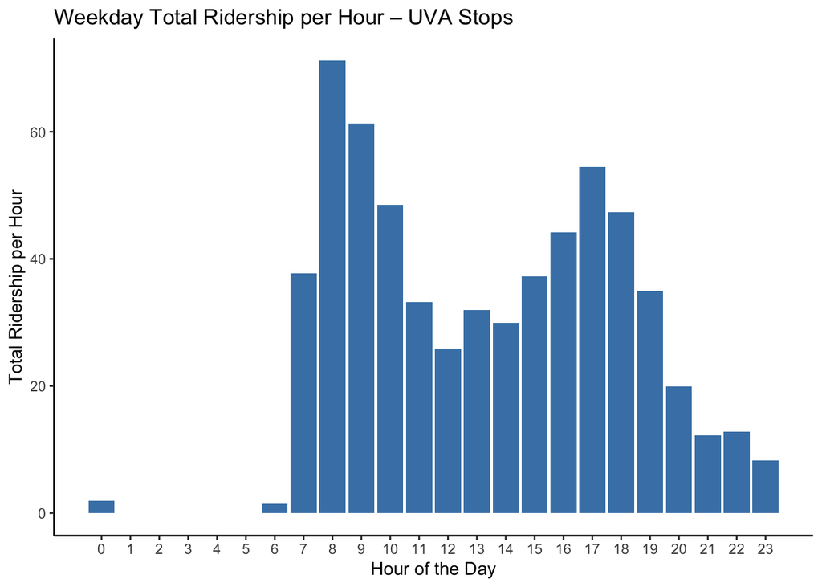

```r
#Filter to weekdays
df_weekdays <- df %>%
  filter(wday(Date_Time) %in% 2:6)

#Total ridership per hour per day per StopType
hourly_totals <- df_weekdays %>%
  group_by(StopType, Date, Hour) %>%
  summarise(Daily_Total_Ridership = sum(Count, na.rm = TRUE), .groups = "drop")

#Average ridership per hour per StopType
hourly_avg <- hourly_totals %>%
  group_by(StopType, Hour) %>%
  summarise(Average_Ridership = mean(Daily_Total_Ridership, na.rm = TRUE), .groups = "drop")

ggplot(filter(hourly_avg, StopType == "UVA Stop"),
       aes(x = Hour, y = Average_Ridership)) +
  geom_bar(stat = "identity", fill = "steelblue") +
  labs(title = "Weekday Total Ridership per Hour – UVA Stops",
       x = "Hour of the Day", y = "Total Ridership per Hour") +
  theme_classic() +
  scale_x_continuous(breaks = seq(0, 23, 1))
```

### Histogram for non-UVA ridership

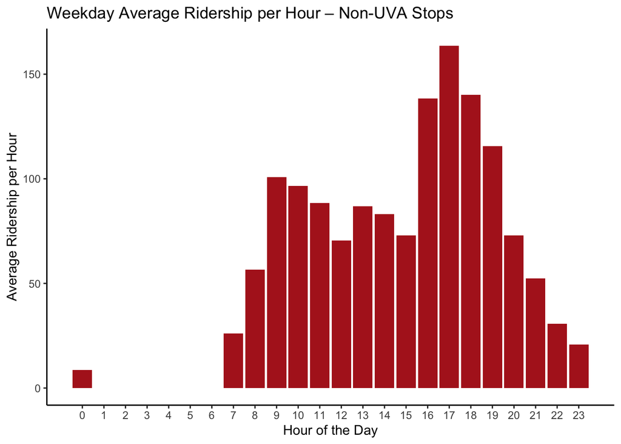

```r
ggplot(filter(hourly_avg, StopType == "Non-UVA Stop"),
       aes(x = Hour, y = Average_Ridership)) +
  geom_bar(stat = "identity", fill = "firebrick") +
  labs(title = "Weekday Average Ridership per Hour – Non-UVA Stops",
       x = "Hour of the Day", y = "Average Ridership per Hour") +
  theme_classic() +
  scale_x_continuous(breaks = seq(0, 23, 1))
```

## Second Research Question

My second research question was “What is the busiest area?” I first downloaded the Charlottesville region map from the Charlottesville open data. Then I used the leaflet package, a widget that can be rendered on HTML pages. I imported the Charlottesville map, and used the coordinates information of each stop from the Transit_2020 data set to create a heatmap and a dot density map. In addition, I created a marker using the coordinates of UVA, just to see what’s the impact of UVA population on the stops of the buses.

```r
#classify uva and non-uva
df_uva <- df %>%
  filter(StopType == "UVA Stop") %>%
  select(Latitude, Longitude, Count)

df_nonuva <- df %>%
  filter(StopType == "Non-UVA Stop") %>%
  select(Latitude, Longitude, Count)
```

```r
#Create the boundary of Charlottesville
charlottesville_boundary <- st_read("Municipal_Boundary_Area.geojson")
```

```r
charlottesville_boundary <- st_zm(charlottesville_boundary)

#Providing the UVA central grounds coordinates for a UVA marker
uva_lat <- 38.0336
uva_lon <- -78.5070

heat_map <- leaflet(df_uva)|>
  addTiles() |>
  addHeatmap(
    lng = ~Longitude, lat = ~Latitude,
    intensity = ~Count,
    blur = 20, radius = 15, max = max(df_uva$Count, na.rm = TRUE)
)|>
  addPolygons(
    data = charlottesville_boundary,
    color = "blue", weight = 2, fillOpacity = 0.1,
    popup = "Charlottesville City Boundary"
  ) |>
  addMarkers(
    lng = uva_lon, lat = uva_lat,
    popup = "University of Virginia",
    label = "University of Virginia",
    labelOptions = labelOptions(noHide = TRUE, direction = "top", textOnly = TRUE)
  ) |>
  setView(lng = -78.5070, lat = 38.0336, zoom = 13)
```

Save the interactive map as an HTML file and capture the HTML map as a PNG image

```r
#saveWidget(heat_map, "heat_map.html")
#webshot("heat_map.html", file = "heat_map.png")
```

*I created another heat map for non-UVA-affiliated bus.

```r
heat_map <- leaflet(df_nonuva)|>
  addTiles() |>
  addHeatmap(
    lng = ~Longitude, lat = ~Latitude,
    intensity = ~Count,
    blur = 20, radius = 15, max = max(df_nonuva$Count, na.rm = TRUE)
)|>
  addPolygons(
    data = charlottesville_boundary,
    color = "blue", weight = 2, fillOpacity = 0.1,
    popup = "Charlottesville City Boundary"
  ) |>
  addMarkers(
    lng = uva_lon, lat = uva_lat,
    popup = "University of Virginia",
    label = "University of Virginia",
    labelOptions = labelOptions(noHide = TRUE, direction = "top", textOnly = TRUE)
  ) |>
  setView(lng = -78.5070, lat = 38.0336, zoom = 13)
heat_map
```

[interactive chart not shown]